# Object Oriented Programming - OOP

Object-oriented programming is a programming paradigm based on the concept of "objects", which can contain data, in the form of fields, and code, in the form of procedures.

based on tutorialspoint Python 3 [notes](https://www.tutorialspoint.com/python3/python_classes_objects.htm)

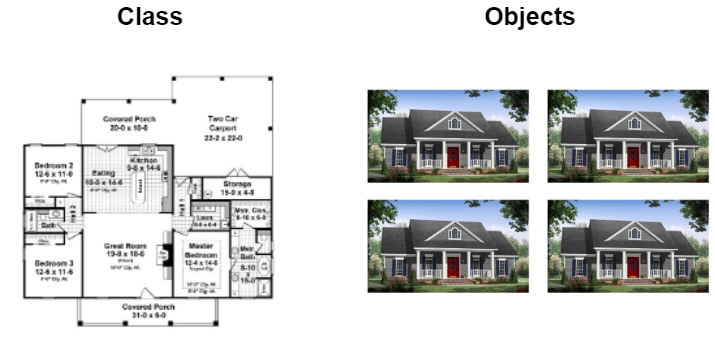

## Class

A user-defined prototype for an object that defines a set of attributes that characterize any object of the class. The attributes are data members (class variables and instance variables) and methods, accessed via dot notation.

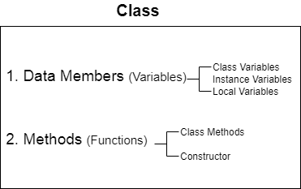

```python
class Rectangle:

    count=0 #this is a class variable, declared outside of methods

    #this is the constructor, one per class, declared using __init__
    def __init__(self):
        self.width=0 #these are instance variables
        self.height=0
        self.area=0
        self.perimeter=0
        print('Constructor called!')

    #this is a method
    def findArea(self):
        self.area=self.width*self.height

    #this is a method
    def findPerimeter(self):

        oneSideLength=self.height+self.width        #this is a local variable
        self.perimeter=2*oneSideLength    #this is an instance variable

    #this is a method
    def printDetails(self):

        print('width:',self.width)
        print('height:',self.height)
        print('area:',self.area)
        print('perimeter:',self.perimeter)
        print('count:',self.count)
```

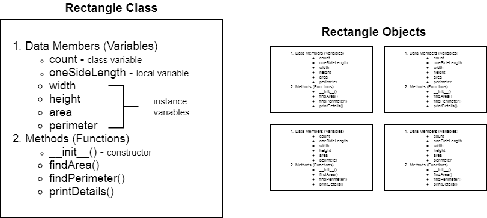

```python
rect1=Rectangle()

rect1.printDetails()
```

```
Constructor called!
width: 0
height: 0
area: 0
perimeter: 0
count: 0
```

[output not shown]

```python
rect2=Rectangle()

rect2.height=10
rect2.width=20

rect2.printDetails()
```

```
Constructor called!
width: 20
height: 10
area: 0
perimeter: 0
count: 0
```

```python
rect3=Rectangle()

rect3.height=10
rect3.width=20

rect3.findArea()
rect3.findPerimeter()

rect3.printDetails()
```

```
Constructor called!
width: 20
height: 10
area: 200
perimeter: 60
count: 0
```

## Constructor

The first method `__init__()` is a special method, which is called class constructor or initialization method that Python calls when you create a new instance of this class.

You declare other class methods like normal functions with the exception that the first argument to each method is self. Python adds the self argument to the list for you; you do not need to include it when you call the methods.

```python
class Rectangle:

    count=0 #this is a class variable, declared outside of methods

    #this is the constructor, one per class, declared using __init__
    def __init__(self,w,h):
        self.width=w  #these are instance variables
        self.height=h
        self.area=0
        self.perimeter=0
        print('Constructor called!')

    #this is a method
    def findArea(self):
        self.area=self.width*self.height

    #this is a method
    def findPerimeter(self):

        oneSideLength=self.height+self.width        #this is a local variable
        self.perimeter=2*oneSideLength    #this is an instance variable

    #this is a method
    def printDetails(self):

        print('width:',self.width)
        print('height:',self.height)
        print('area:',self.area)
        print('perimeter:',self.perimeter)
        print('count:',self.count)
```

```python
rect1=Rectangle(10,30)
rect1.findArea()
rect1.findPerimeter()
rect1.printDetails()
```

```
Constructor called!
width: 10
height: 30
area: 300
perimeter: 80
count: 0
```

### Methods of using the constructor

```python
class Rectangle:

    count=0 #this is a class variable, declared outside of methods

    #this is the constructor, one per class, declared using __init__
    def __init__(self,w,h):
        self.width=w  #these are instance variables
        self.height=h
        self.area=0
        self.perimeter=0
        print('Constructor called!')

    #this is a method
    def findArea(self):
        self.area=self.width*self.height

    #this is a method
    def findPerimeter(self):

        oneSideLength=self.height+self.width        #this is a local variable
        self.perimeter=2*oneSideLength    #this is an instance variable

    #this is a method
    def printDetails(self):

        print('width:',self.width)
        print('height:',self.height)
        print('area:',self.area)
        print('perimeter:',self.perimeter)
        print('count:',self.count)
```

```python
rect1=Rectangle()
rect1.findArea()
rect1.findPerimeter()
rect1.printDetails()
```

```
---------------------------------------------------------------------------
TypeError                                 Traceback (most recent call last)
<ipython-input-39-548e1053d21d> in <module>
----> 1 rect1=Rectangle()
      2 rect1.findArea()
      3 rect1.findPerimeter()
      4 rect1.printDetails()

TypeError: __init__() missing 2 required positional arguments: 'w' and 'h'
```

## We can use the Default argument and Keyword argument function types to overcome this issue

```python
class Rectangle:

    count=0 #this is a class variable, declared outside of methods

    #this is the constructor, one per class, declared using __init__
    def __init__(self,width=0,height=0):
        self.width=width  #these are instance variables
        self.height=height
        self.area=0
        self.perimeter=0
        print('Constructor called!')

    #this is a method
    def findArea(self):
        self.area=self.width*self.height

    #this is a method
    def findPerimeter(self):

        oneSideLength=self.height+self.width        #this is a local variable
        self.perimeter=2*oneSideLength    #this is an instance variable

    #this is a method
    def printDetails(self):

        print('width:',self.width)
        print('height:',self.height)
        print('area:',self.area)
        print('perimeter:',self.perimeter)
        print('count:',self.count)
```

```python
rect1=Rectangle(10,20)
rect1.findArea()
rect1.findPerimeter()
rect1.printDetails()
```

```
Constructor called!
width: 10
height: 20
area: 200
perimeter: 60
count: 0
```

```python
rect2=Rectangle()
rect2.findArea()
rect2.findPerimeter()
rect2.printDetails()
```

```
Constructor called!
width: 0
height: 0
area: 0
perimeter: 0
count: 0
```

```python
rect1=Rectangle(height=20,width=10)
rect1.findArea()
rect1.findPerimeter()
rect1.printDetails()
```

```
Constructor called!
width: 10
height: 20
area: 200
perimeter: 60
count: 0
```

## Class Variable

A variable that is shared by all instances of a class. Class variables are defined within a class but outside any of the class's methods. Class variables are not used as frequently as instance variables are.

```python
class Rectangle:

    count=0 #this is a class variable, declared outside of methods

    #this is the constructor, one per class, declared using __init__
    def __init__(self,width=0,height=0):
        self.width=width  #these are instance variables
        self.height=height
        print('Constructor called!, count:',self.count)
        Rectangle.count=Rectangle.count+1
```

```python
rect1=Rectangle(height=20,width=10)
```

```
Constructor called!, count: 0
```

```python
rect2=Rectangle()
```

```
Constructor called!, count: 1
```

```python
rect3=Rectangle(40,30)
```

```
Constructor called!, count: 2
```

## Class Inheritance

Instead of starting from a scratch, you can create a class by deriving it from a pre-existing class by listing the parent class in parentheses after the new class name.

The child class inherits the attributes of its parent class, and you can use those attributes as if they were defined in the child class. A child class can also override data members and methods from the parent.

[figure not shown]

```python
class Rectangle:

    #this is the constructor, one per class, declared using __init__
    def __init__(self,width=0,height=0):
        self.width=width  #these are instance variables
        self.height=height
        self.area=0
        self.perimeter=0
        print('Rectangle Constructor called!')

    #this is a method
    def findArea(self):
        self.area=self.width*self.height

    #this is a method
    def findPerimeter(self):

        oneSideLength=self.height+self.width        #this is a local variable
        self.perimeter=2*oneSideLength    #this is an instance variable

    #this is a method
    def printDetails(self):

        print('width:',self.width)
        print('height:',self.height)
        print('area:',self.area)
        print('perimeter:',self.perimeter)
```

```python
class Square(Rectangle):

    def __init__(self,length=0):

        self.lengthOfSide=length

    def printSquareDetails(self):

        print('length of one side:',self.lengthOfSide)
```

```python
sq1=Square()
sq1.printSquareDetails()
```

```
length of one side: 0
```

```python
sq2=Square(10)
sq2.printSquareDetails()
```

```
length of one side: 10
```

```python
class Square(Rectangle):

    def __init__(self,length=0):

        self.lengthOfSide=length
        self.width=self.height=self.lengthOfSide

    def printSquareDetails(self):

        print('length of one side:',self.lengthOfSide)
        print('area:',self.area)
        print('perimeter:',self.perimeter)
```

```python
sq1=Square(10)            #own constructor
sq1.findArea()            #parent method
sq1.findPerimeter()       #parent method
sq1.printSquareDetails()  #own method
```

```
length of one side: 10
area: 100
perimeter: 40
```

```python
sq1.printDetails()       #parent method
```

```
width: 10
height: 10
area: 100
perimeter: 40
```

## Super function

By using the super() function, you do not have to use the name of the parent element, it will automatically inherit the methods and properties from its parent.

```python
class Square(Rectangle):

    def __init__(self,length=0):

        super().__init__(length,length)

    def printSquareDetails(self):

        print('length of one side:',self.lengthOfSide)
        print('area:',self.area)
        print('perimeter:',self.perimeter)
```

```python
sq1=Square(10)            #own constructor
sq1.findArea()            #parent method
sq1.findPerimeter()       #parent method
sq1.printDetails()  #own method
```

```
Rectangle Constructor called!
width: 10
height: 10
area: 100
perimeter: 40
```

## Overriding Methods

You can always override your parent class methods. One reason for overriding parent's methods is because you may want special or different functionality in your subclass.

```python
class Rectangle:

    #this is the constructor, one per class, declared using __init__
    def __init__(self,width=0,height=0):
        self.width=width  #these are instance variables
        self.height=height
        self.area=0
        self.perimeter=0
        print('Rectangle Constructor called!')

    #this is a method
    def findArea(self):
        self.area=self.width*self.height

    #this is a method
    def findPerimeter(self):

        oneSideLength=self.height+self.width        #this is a local variable
        self.perimeter=2*oneSideLength    #this is an instance variable

    #this is a method
    def printDetails(self):

        print("====Rectangle printDetails method====")

        print('width:',self.width)
        print('height:',self.height)
        print('area:',self.area)
        print('perimeter:',self.perimeter)
```

```python
class Square(Rectangle):

    def __init__(self,length=0):

        self.lengthOfSide=length
        self.width=self.height=self.lengthOfSide

    def printDetails(self):

        print("====Square printDetails method====")

        print('length of one side:',self .lengthOfSide)
        print('area:',self.area)
        print('perimeter:',self.perimeter)
```

```python
sq1=Square(10)            #own constructor
sq1.findArea()            #parent method
sq1.findPerimeter()       #parent method
sq1.printDetails()        #own method
```

```
====Square printDetails method====
length of one side: 10
area: 100
perimeter: 40
```

# QUIZ 01

Class student has the marks obtained by a student for the three modules. The marks are stored in a list called mark. Implement the class with the given data members (variables) and the methods (functions)

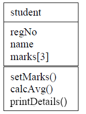

1. Add a constructor with parameters to assign regNo and name of the student.
2. `setMarks()` member function stores the three marks given as parameters in the marks array.
3. `calcAvg()` member function returns the average mark of the modules.
4. Display the details of the student with the marks obtained for the modules and the average using `printDetails()` method.
5. Create two student objects and assign the marks for the three modules. Calculate the average mark and display the details using the member functions implemented.
6. Create another method called `writeDetails()` which takes a file name of .txt file and append the student details (reg no, name, marks and avarage) to that file (see the file operations tutorial)

```python
class Student():

    def __init__(self,reg=0,name=0):
        self.reg=reg
        self.name=name
        self.marks=[0,0,0]

    def setMarks(self,maths,phy,chem):

        self.marks[0]=maths
        self.marks[1]=phy
        self.marks[2]=chem

    def calAvg(self):

        return sum(self.marks)/3.0

    def printDetails(self):

        print('name:',self.name)
        print('reg no:',self.reg)
        print('marks:',self.marks)
        print('avg:',self.calAvg())

    def writeDetails(self,fileName):

        file=open(fileName,'a')

        avg=self.calAvg()

        file.write(str([self.name,self.reg,self.marks,avg])+'\n')
        file.close()
```

```python
std1=Student(1,'John')
std1.setMarks(88,91,92)
std1.printDetails()
std1.writeDetails('student.txt')
```

```
name: John
reg no: 1
marks: [88, 91, 92]
avg: 90.33333333333333
```

```python
print(std1.calAvg())
```

```
90.33333333333333
```

# QUIZ 02

Create the class `Cuboid` which consists of,

1. data members -`height` (to stores the height) -`width` (to stores the width) -`length` (to stores the length) -`area` (to stores the area) -`perimeter` (to stores the perimeter)
2. methods -`calVolume()` (to calculate the volume of the cuboid) -`calArea()` (to calculate the area of the cuboid) -`printDetails()` (to print the details - data members of the cuboid)

inherit the class `Cube` from class `Cuboid` which has own attributes,

1. data members -`lengthOfSide`
2. methods -`printDetails()` (to print the details of cube)

## Task

Create the following objects using a python code and calculate the total area and volume of the objects

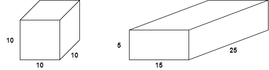

```python
class Cuboid():

    def __init__(self,length,width,height):
        self.length=length
        self.width=width
        self.height=height
        self.area=0
        self.volume=0

    def calArea(self):

        self.area=2*(self.length*self.height+self.length*self.width+self.width*self.height)
        return self.area

    def calVolume(self):

        self.volume=self.length*self.height*self.width
        return self.volume

    def printDetails(self):

        print('Width:',self.width)
        print('Length:',self.length)
        print('Height:',self.height)
        print('Area:',self.area)
        print('Volume:',self.volume)
```

```python
class Cube(Cuboid):

    def __init__(self,length):
        self.lengthOfSide=length

        self.length=self.lengthOfSide
        self.width=self.lengthOfSide
        self.height=self.lengthOfSide

    def printDetails(self):

        print('Length of one side:',self.lengthOfSide)
        print('Area:',self.area)
        print('Volume:',self.volume)
```

```python
cube1=Cube(10)
cuboid1=Cuboid(5,15,25)

totalArea=cube1.calArea()+cuboid1.calArea()
totalVolume=cube1.calVolume()+cuboid1.calVolume()

print('total area:',totalArea)
print('total volume:',totalVolume)
```

```
total area: 1750
total volume: 2875
```